# Introduction_to_datascience

## Statistiques descriptives

- moyenne, variance, statistiques d'ordre (médiane, min, max, quartiles)

Pour des données $x[i]$, $i=0..N-1$

- moyenne $\mu_N = \frac{1}{N} \sum_{i=0}^{N-1} x[i]$
- variance $\sigma^2_N = \frac{1}{N-1} \sum_{i=0}^{N-1} (x[i]-\mu_N)^2$
- médiane $\operatorname{P}(X\leq m) \geq \frac{1}{2}\text{ et }\operatorname{P}(X\geq m) \geq \frac{1}{2}\,\!$

Exemple : exécuter ceci plusieurs fois

```python
x = np.random.normal(size=1000)
mu = np.mean(x)
v = np.var(x)
m = np.median(x)
print(mu, v, m)
```

```
0.029681470622051818 0.9299019297175699 0.03495275595554932
```

Autre exemple : le [Anscombe's quartet](https://en.wikipedia.org/wiki/Anscombe's_quartet)

Anscombe, F. J. (1973). "Graphs in Statistical Analysis". American Statistician. 27 (1): 17–21

```python
data = pd.read_csv("anscombes.csv")
```

```python
data.drop(columns='id', inplace=True)
```

```python
np.corrcoef(group['x'], group['y'])[0,1]
```

```
0.8165214368885028
```

```python
for label in  ['I', 'II', 'III', 'IV']:
    group = data[data['dataset']==label]
    print(f"Groupe {label}")
    print(group)
    print(group.describe()[0:3])
    print('corr   ', np.corrcoef(group['x'], group['y'])[0,1])
    print('='*28)
```

```
Groupe I
   dataset     x      y
0        I  10.0   8.04
1        I   8.0   6.95
2        I  13.0   7.58
3        I   9.0   8.81
4        I  11.0   8.33
5        I  14.0   9.96
6        I   6.0   7.24
7        I   4.0   4.26
8        I  12.0  10.84
9        I   7.0   4.82
10       I   5.0   5.68
               x          y
count  11.000000  11.000000
mean    9.000000   7.500909
std     3.316625   2.031568
corr    0.81642051634484
============================
Groupe II
   dataset     x     y
11      II  10.0  9.14
12      II   8.0  8.14
13      II  13.0  8.74
14      II   9.0  8.77
15      II  11.0  9.26
16      II  14.0  8.10
17      II   6.0  6.13
18      II   4.0  3.10
19      II  12.0  9.13
20      II   7.0  7.26
21      II   5.0  4.74
               x          y
count  11.000000  11.000000
mean    9.000000   7.500909
std     3.316625   2.031657
corr    0.8162365060002428
============================
Groupe III
   dataset     x      y
```

[output cut: 21 more lines]

```
35      IV   8.0   7.71
36      IV   8.0   8.84
37      IV   8.0   8.47
38      IV   8.0   7.04
39      IV   8.0   5.25
40      IV  19.0  12.50
41      IV   8.0   5.56
42      IV   8.0   7.91
43      IV   8.0   6.89
               x          y
count  11.000000  11.000000
mean    9.000000   7.500909
std     3.316625   2.030579
corr    0.8165214368885028
============================
```

Dans les 4 groupes, on a

- le même nombre de données
- les mêmes moyennes
- les mêmes variances
- les mêmes coefficients de corrélation

Et pourtant, ce ne sont pas les mêmes données !

==> Il faut visualiser !

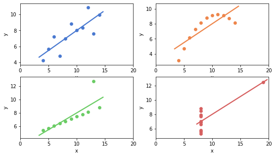

```python
fig, ax = plt.subplots(2,2, figsize=(9,5))
colors = sns.color_palette('muted')
aax = ax.reshape(-1)
n = 0
for label,group in data.groupby('dataset'):
    #print(group)
    #sns.scatterplot(x='x', y='y', color = colors[n], data=group, ax=aax[n])
    sns.regplot(x='x', y='y', color = colors[n], data=group, ci=None,  ax=aax[n])
    aax[n].set_xlim(0,20)
    n = n + 1
```

## La distribution des données

On examine quelle est la distribution des données, car cela peut être utilisé dans la détection de valeurs aberrantes. On souhaite souvent que les données soient gaussiennes, car l'optimalité de certaines méthodes repose sur cette hypothèse.

### Distribution gaussienne

Rappelons ce qu'est une distribution gaussienne (ou normale)

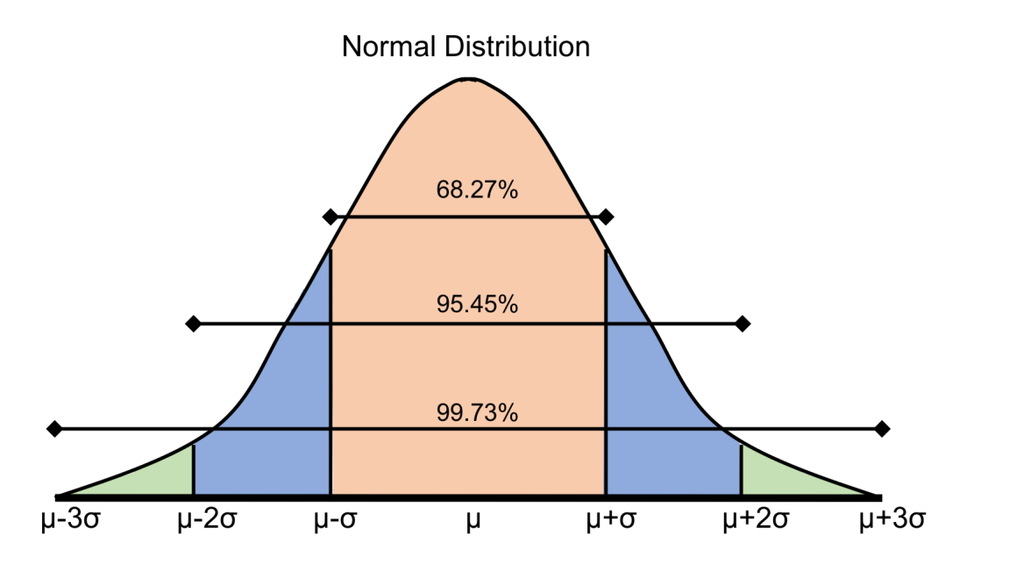

et son importance (seulement deux paramètres, lien avec les moindes carrés, théorème central limite)

### Histogramme

Pour des données *quantitatives*, on peut utiliser un histogramme.

Le "Iris dataset" (Fisher 1936)

```python
iris = pd.read_csv("iris.csv")
iris.head()
```

|  | sepal_length | sepal_width | petal_length | petal_width | species |
| --- | --- | --- | --- | --- | --- |
| 0 | 5.1 | 3.5 | 1.4 | 0.2 | setosa |
| 1 | 4.9 | 3.0 | 1.4 | 0.2 | setosa |
| 2 | 4.7 | 3.2 | 1.3 | 0.2 | setosa |
| 3 | 4.6 | 3.1 | 1.5 | 0.2 | setosa |
| 4 | 5.0 | 3.6 | 1.4 | 0.2 | setosa |

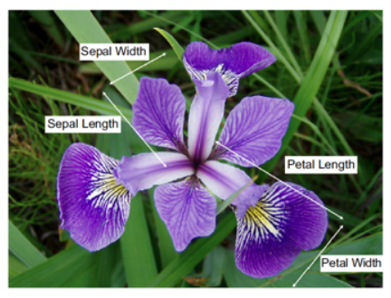

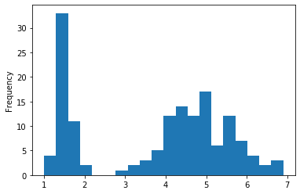

```python
iris['petal_length'].plot(kind="hist", bins=20)
```

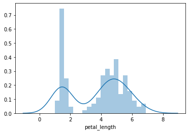

```python
sns.distplot(iris['petal_length'], hist=True, bins=20)
```

*Notez que les amplitudes ne sont plus les mêmes : on est passé du nombre d'éléments dans chaque intervalle à la fréquence (et les labels par défaut sont confus)*

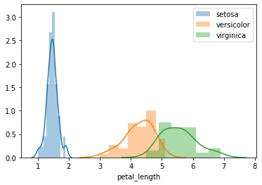

```python
groups = iris.groupby('species')
for l,group in groups:
    sns.distplot(group['petal_length'], hist=True, label=l)
plt.legend()
```

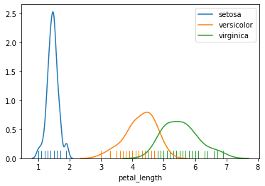

```python
groups = iris.groupby('species')
for l,group in groups:
    sns.distplot(group['petal_length'], hist=False,rug=True, label=l)
plt.legend()
```

NB - Construction des densités estimées : typiquement on convolue la distribution empirique avec un noyau gaussien

Attention, cela peut aussi piéger

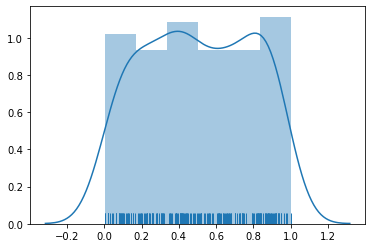

```python
x = np.random.uniform(size=200) # <-- le support est [0,1]
sns.distplot(x, hist=True,rug=True, label=l)
```

### Boxplot

On peut également utiliser les *boxplot* ou "boîtes à moustaches", qui permettent de résumer les principales caractéristiques

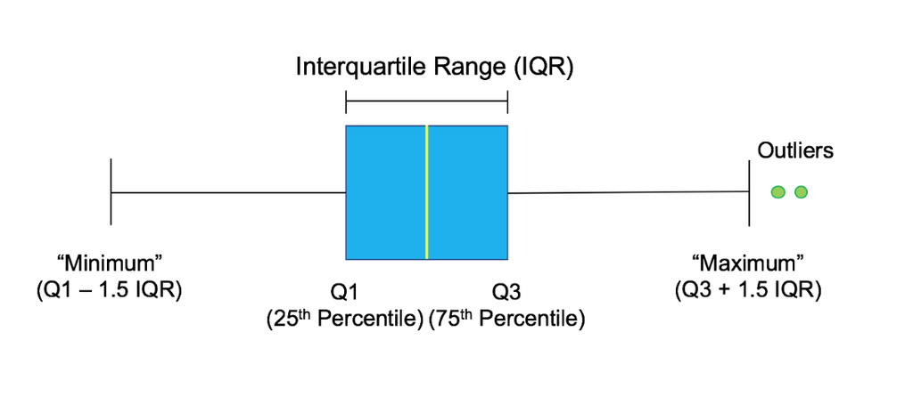

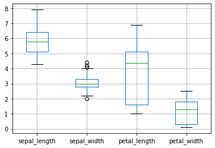

```python
iris.boxplot()
```

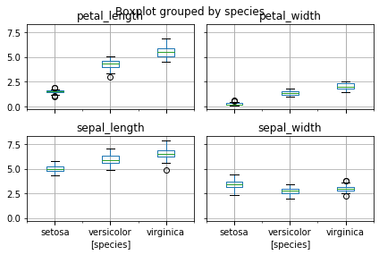

```python
_ = iris.boxplot(by='species')
plt.tight_layout()
```

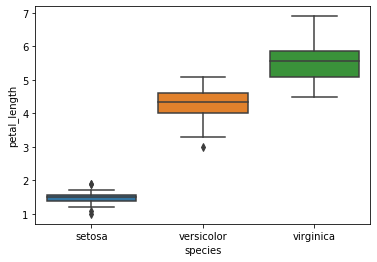

```python
sns.boxplot(data=iris, x='species', y='petal_length')
```

Une variante : les "violin plot"

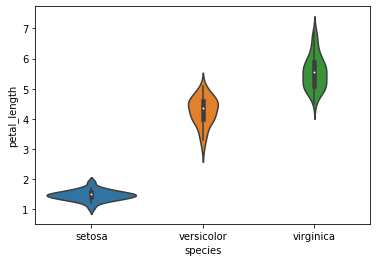

```python
sns.violinplot(data=iris, x='species', y='petal_length')
```

### Scatterplots

Examiner graphiquement les relations entre les variables

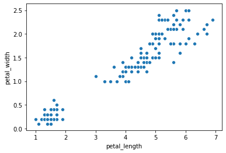

```python
_ = sns.scatterplot(data=iris, x='petal_length', y='petal_width')
```

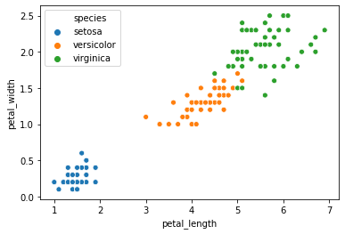

```python
_ = sns.scatterplot(data=iris, x='petal_length', y='petal_width', hue='species')
```

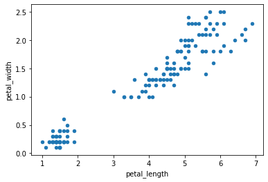

```python
# version pandas
iris.plot(kind='scatter', x='petal_length', y='petal_width')
```

### Rechercher des relations linéaires

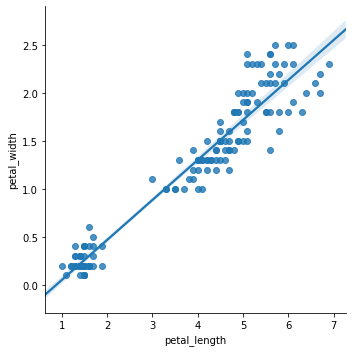

```python
_ = sns.lmplot(data=iris, x='petal_length', y='petal_width')
```

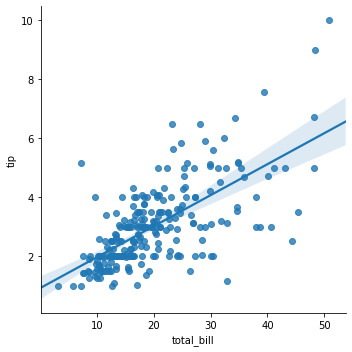

```python
#sns.set(color_codes=True)
tips = sns.load_dataset("tips")
g = sns.lmplot(x="total_bill", y="tip", data=tips)
```

### Examiner des corrélations

```python
d1 = np.random.normal(size=200)
d2 = np.random.uniform(size=200)
d3 = np.random.uniform(size=200)
d4 = np.random.normal(size=200)
x1 = d1
x2 = d1 + 4*d2
data = pd.DataFrame(data={'x1':x1, 'x2':x2, 'x3':d3, 'x4':d4})
print(data)

X = [x1 , x2]
print("Covariance ", np.cov(x1,x2), '\n')
print("Corrcoeff ", np.corrcoef(x1,x2))
print("data cov \n", data.cov(), '\n')
print("data cor \n", data.corr(), '\n')
```

```
           x1        x2        x3        x4
0    0.316768  2.814592  0.873406  0.069811
1    2.147014  5.611184  0.346725  0.957980
2    0.897756  4.834162  0.822035 -1.390041
3    0.363474  4.333572  0.110854 -0.037080
4   -2.143903 -1.670018  0.313583 -0.301206
..        ...       ...       ...       ...
195 -0.182990  3.324510  0.601581 -0.655673
196  0.561518  2.639926  0.616854 -0.117762
197 -0.286892  2.693906  0.494214  0.163018
198  0.653776  3.438557  0.605703  0.708382
199 -0.208451  0.756032  0.944310  0.533536

[200 rows x 4 columns]
Covariance  [[1.02378596 1.21957841]
 [1.21957841 2.80630679]]

Corrcoeff  [[1.         0.71951122]
 [0.71951122 1.        ]]
data cov
           x1        x2        x3        x4
x1  1.023786  1.219578 -0.036625  0.003404
x2  1.219578  2.806307 -0.033806 -0.060458
x3 -0.036625 -0.033806  0.078198  0.004596
x4  0.003404 -0.060458  0.004596  1.097430

data cor
           x1        x2        x3        x4
x1  1.000000  0.719511 -0.129443  0.003211
x2  0.719511  1.000000 -0.072166 -0.034451
x3 -0.129443 -0.072166  1.000000  0.015687
x4  0.003211 -0.034451  0.015687  1.000000
```

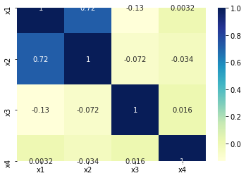

```python
# Heatmap...
sns.heatmap(data.corr(), annot=True,  cmap="YlGnBu", cbar=True)
```

### Visualiser les données conjointement

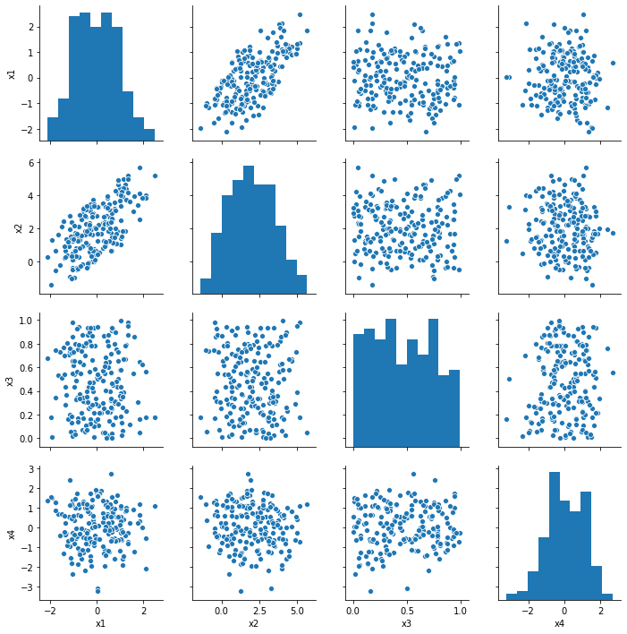

```python
sns.pairplot(data)
```

**Attention**

```python
theta = np.random.uniform(0, 2*np.pi, size=1000)
```

```python
x = np.cos(theta)
y = np.sin(theta)
df = pd.DataFrame(data = {'x':x, 'y':y})
```

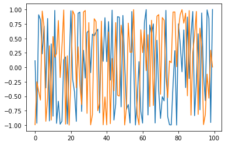

```python
plt.plot(x[0:100])
plt.plot(y[0:100])
```

```python
np.cov(x,y)
```

```
array([[ 0.49224044, -0.0100941 ],
       [-0.0100941 ,  0.50811854]])
```

```python
# Vérif du calcul de corrélation :
mx=np.mean(x)
my=np.mean(y)
1/(len(x)-1)*np.sum((x-mx)*(y-my))
```

```
-0.010094104815132605
```

Visualisation conjointe...

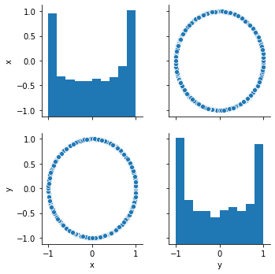

```python
sns.pairplot(df)
```

Ce n'est pas parce qu'il n'y a pas de corrélation, qu'il n'y a pas de dépendance !

# Pandas

La bibliothèque [Pandas](http://pandas.pydata.org/) est une bibliothèque d'analyse de données qui est actuellement absolument incontournable. On présente ici quelques fonctionnalités, étant bien entendu que cela ne fait qu'effleurer le sujet et ne peut remplacer la consultation de la [documentation](http://pandas.pydata.org/pandas-docs/stable/) et l'expérimentation.

```python
from IPython.display import IFrame
IFrame('http://pandas.pydata.org/', width=700, height=350)
```

[interactive chart not shown]

Rien que pour son support des entrées sorties, c'est un outil indispensable : [entrées-sorties](https://pandas.pydata.org/pandas-docs/stable/user_guide/io.html)

## Rappel - Numpy

```python
#%%file pouet.py
#1d vector
data = np.arange(20)
print(data, "\n\nshape :", data.shape, "\n\ntype : ", type(data))
#print(f"data {data}")
```

```
[ 0  1  2  3  4  5  6  7  8  9 10 11 12 13 14 15 16 17 18 19]

shape : (20,)

type :  <class 'numpy.ndarray'>
```

```python
# make it a 4,5 array
data = np.arange(20).reshape(4, 5)
print(data, "\n\nshape :", data.shape, "\n\ntype : ", type(data))
```

```
[[ 0  1  2  3  4]
 [ 5  6  7  8  9]
 [10 11 12 13 14]
 [15 16 17 18 19]]

shape : (4, 5)

type :  <class 'numpy.ndarray'>
```

```python
# extraire une colonne
data[:, 1]
```

```
array([ 1,  6, 11, 16])
```

```python
# extraire une ligne
data[1, :]
```

```
array([5, 6, 7, 8, 9])
```

```python
# slices
data[2:4, 2:4]
```

```
array([[12, 13],
       [17, 18]])
```

## Quelques fonctions utiles pour la présentation

```python
def random_letters(size=1,maxletter=52):
    import string
    return [string.ascii_letters[k]
            for k in np.random.randint(0,maxletter,size=size)]
z=random_letters(12,52)
z
```

```
['L', 'y', 'w', 'i', 'L', 'u', 'i', 'd', 'v', 'W', 'q', 'B']
```

```python
def disp(expr):
    from IPython.display import HTML, display
    display(HTML( '<b style="color:blue"> {} </b>'.format(expr)))
    print(eval(expr))
disp("z")
disp("[x.upper() for x in z]")
```

**z**

```
['L', 'y', 'w', 'i', 'L', 'u', 'i', 'd', 'v', 'W', 'q', 'B']
```

**[x.upper() for x in z]**

```
['L', 'Y', 'W', 'I', 'L', 'U', 'I', 'D', 'V', 'W', 'Q', 'B']
```

```python
def convint(x):
    import re
    if x is not np.nan:
        if isinstance(x,str):
            x=x.replace('\xa0','')
            x=x.replace(' ','')
            x=re.sub(r'\[\S+\]','',x)
        if x=='': return 0
        if x=='NR': return 0
        try:
            return int(x)
        except:
            return np.nan
```

[figure not shown]

# DataFrames pandas

## Introduction

Le nom de pandas dérive de `panel data`, un terme courant en économétrie. Un article de référence est [pyhpc2011](http://www.dlr.de/sc/Portaldata/15/Resources/dokumente/pyhpc2011/submissions/pyhpc2011_submission_9.pdf).

La structure fondamentale de pandas est celle des dataframes. La figure suivante est extraite du livre de [Wes McKinney](https://www.amazon.fr/Python-Data-Analysis-Wes-Mckinney/dp/1449319793/ref=sr_1_1?ie=UTF8&qid=1443455134&sr=8-1&keywords=Python+for+Data+Analysis)

[figure not shown]

```python
p1 = pd.read_csv("dpts_pop.csv")
p1.index = p1.iloc[:, 0].values  # prend comme nouvel index le contenu de la colonne 0
p1 = p1.drop(['Unnamed: 0', '2015'], axis=1)  # supprime la colonne
p1.columns = p1.columns.astype(int)
p1 = p1.applymap(convint)
p1.head()
```

|  | 1931 | 1999 | 2008 | 2010 | 2011 | 2012 |
| --- | --- | --- | --- | --- | --- | --- |
| Nord | 2029449.0 | 2555020 | 2564959 | 2576770.0 | 2579208.0 | 2587128 |
| Paris | 2891020.0 | 2125246 | 2211297 | 2243833.0 | 2249975.0 | 2240621 |
| Bouches-du-Rhône | 1101672.0 | 1835719 | 1966005 | 1972018.0 | 1975896.0 | 1984784 |
| Hauts-de-Seine | 949231.0 | 1428881 | 1549619 | 1572490.0 | 1581628.0 | 1586434 |
| Seine-Saint-Denis | 769315.0 | 1382861 | 1506466 | 1522048.0 | 1529928.0 | 1538726 |

```python
pop = p1.copy()
```

```python
p2 = pd.read_csv("dpts_tab.csv")
p2 = p2.drop(labels=[0, 1], axis=0)
p2.index = p1.index
p2 = p2.drop(labels=['Unnamed: 0'], axis=1)
sup = p2['Superficie'].copy()
sup = sup.map(convint)
sup.head()
```

```
Nord                 5743
Paris                 105
Bouches-du-Rhône     5087
Hauts-de-Seine        176
Seine-Saint-Denis     236
Name: Superficie, dtype: int64
```

On a des méthodes pour afficher le début ou la fin du dataframe, ainsi qu'une description statistique

```python
pop.head()
```

|  | 1931 | 1999 | 2008 | 2010 | 2011 | 2012 |
| --- | --- | --- | --- | --- | --- | --- |
| Nord | 2029449.0 | 2555020 | 2564959 | 2576770.0 | 2579208.0 | 2587128 |
| Paris | 2891020.0 | 2125246 | 2211297 | 2243833.0 | 2249975.0 | 2240621 |
| Bouches-du-Rhône | 1101672.0 | 1835719 | 1966005 | 1972018.0 | 1975896.0 | 1984784 |
| Hauts-de-Seine | 949231.0 | 1428881 | 1549619 | 1572490.0 | 1581628.0 | 1586434 |
| Seine-Saint-Denis | 769315.0 | 1382861 | 1506466 | 1522048.0 | 1529928.0 | 1538726 |

```python
pop.tail()
```

|  | 1931 | 1999 | 2008 | 2010 | 2011 | 2012 |
| --- | --- | --- | --- | --- | --- | --- |
| Corse-du-Sud | NaN | 118593 | 140953 | 143600.0 | 145846.0 | 145429 |
| Territoire de Belfort | 99403.0 | 137408 | 141958 | 142911.0 | 143348.0 | 143940 |
| Hautes-Alpes | 87566.0 | 121419 | 134205 | 136971.0 | 138605.0 | 139554 |
| Creuse | 207882.0 | 124470 | 123907 | 123029.0 | 122560.0 | 121517 |
| Lozère | 101849.0 | 73509 | 76973 | 77082.0 | 77156.0 | 76889 |

```python
pop.describe()
```

|  | 1931 | 1999 | 2008 | 2010 | 2011 | 2012 |
| --- | --- | --- | --- | --- | --- | --- |
| count | 9.60000e+01 | 1.02000e+02 | 1.02000e+02 | 1.01000e+02 | 1.01000e+02 | 1.02000e+02 |
| mean | 4.34762e+05 | 5.91345e+05 | 6.29245e+05 | 6.39852e+05 | 6.42905e+05 | 6.41705e+05 |
| std | 3.76648e+05 | 4.61551e+05 | 4.86831e+05 | 4.91877e+05 | 4.94475e+05 | 4.96596e+05 |
| min | 0.00000e+00 | 0.00000e+00 | 0.00000e+00 | 0.00000e+00 | 0.00000e+00 | 0.00000e+00 |
| 25% | 2.50684e+05 | 2.85509e+05 | 2.86218e+05 | 2.91642e+05 | 2.90891e+05 | 2.84587e+05 |
| 50% | 3.34513e+05 | 4.90266e+05 | 5.09272e+05 | 5.24358e+05 | 5.25931e+05 | 5.13372e+05 |
| 75% | 4.95180e+05 | 7.31838e+05 | 7.93500e+05 | 8.03595e+05 | 8.05642e+05 | 8.06614e+05 |
| max | 2.89102e+06 | 2.55502e+06 | 2.56496e+06 | 2.57677e+06 | 2.57921e+06 | 2.58713e+06 |

```python
pop.info()
```

```
<class 'pandas.core.frame.DataFrame'>
Index: 102 entries, Nord to Lozère
Data columns (total 6 columns):
1931    96 non-null float64
1999    102 non-null int64
2008    102 non-null int64
2010    101 non-null float64
2011    101 non-null float64
2012    102 non-null int64
dtypes: float64(3), int64(3)
memory usage: 5.6+ KB
```

```python
pop.isnull().sum()
```

```
1931    6
1999    0
2008    0
2010    1
2011    1
2012    0
dtype: int64
```

```python
def random_df(size):
    import string
    letters = string.ascii_letters
    return pd.DataFrame(
        np.random.uniform(size=size),
        index=[letters[k] for k in range(size[0])],
        columns=['col_' + str(k) for k in range(size[1])])


a = random_df((4, 5))
a
```

|  | col_0 | col_1 | col_2 | col_3 | col_4 |
| --- | --- | --- | --- | --- | --- |
| a | 0.790970 | 0.829484 | 0.805591 | 0.206488 | 0.837014 |
| b | 0.281623 | 0.803008 | 0.315566 | 0.621690 | 0.149125 |
| c | 0.082088 | 0.233023 | 0.651687 | 0.475572 | 0.199724 |
| d | 0.312712 | 0.452634 | 0.542358 | 0.465796 | 0.929227 |

## Accéder aux données :

Comment extrait-on des données d'un dataframe ?

```python
df = random_df((4, 5))
df
```

|  | col_0 | col_1 | col_2 | col_3 | col_4 |
| --- | --- | --- | --- | --- | --- |
| a | 0.914780 | 0.512856 | 0.177389 | 0.785886 | 0.648835 |
| b | 0.183436 | 0.139598 | 0.125808 | 0.673340 | 0.775406 |
| c | 0.433024 | 0.426433 | 0.034161 | 0.721772 | 0.691749 |
| d | 0.259916 | 0.906896 | 0.561992 | 0.473820 | 0.058767 |

### Les index

Les dataframes possèdent un index pour les lignes et un index pour les colonnes:

```python
disp("df.columns")
disp("df.index")
```

**df.columns**

```
Index(['col_0', 'col_1', 'col_2', 'col_3', 'col_4'], dtype='object')
```

**df.index**

```
Index(['a', 'b', 'c', 'd'], dtype='object')
```

On peut accéder directement **aux colonnes** via

```python
df['col_1']
```

[output not shown]

! (pour un array numpy, disons a, la commande `a[1]` donne accès à la 2e **ligne** de a).

Mais **si on slice**, le slice par défaut est sur les lignes, et ne fonctionne pas sur les colonnes :

```python
disp("df['col_1':'col_2']")
disp("df['a':'c']")
```

**df['col_1':'col_2']**

```
Empty DataFrame
Columns: [col_0, col_1, col_2, col_3, col_4]
Index: []
```

**df['a':'c']**

```
     col_0    col_1    col_2    col_3    col_4
a  0.92034  0.89475  0.86552  0.09942  0.07140
b  0.23628  0.83111  0.40242  0.37007  0.37958
c  0.19456  0.64392  0.43317  0.61135  0.09888
```

`df['a':'c']` retourne un dataframe, dont on peut extraire une colonne, forcément.

```python
disp("df['a':'c']['col_1']")
```

**df['a':'c']['col_1']**

```
a    0.89475
b    0.83111
c    0.64392
Name: col_1, dtype: float64
```

On dispose d'un indiçage explicite et implicite en `loc` et `iloc`, ~ainsi que d'une version hybride, `ix`~.

```python
disp("df")
disp("df.iloc[2,:]   # Axe 0 --> les lignes")
# ici la ligne 2
```

**df**

```
     col_0    col_1    col_2    col_3    col_4
a  0.92034  0.89475  0.86552  0.09942  0.07140
b  0.23628  0.83111  0.40242  0.37007  0.37958
c  0.19456  0.64392  0.43317  0.61135  0.09888
d  0.62180  0.89832  0.72063  0.87545  0.18662
```

**df.iloc[2,:] # Axe 0 --> les lignes**

```
col_0    0.19456
col_1    0.64392
col_2    0.43317
col_3    0.61135
col_4    0.09888
Name: c, dtype: float64
```

```python
disp("df.iloc[:,1]   # Axe 1 --> les colonnes")
# ici la colonne 1
```

**df.iloc[:,1] # Axe 1 --> les colonnes**

```
a    0.89475
b    0.83111
c    0.64392
d    0.89832
Name: col_1, dtype: float64
```

On peut extraire une sous table simplement

```python
disp("df.iloc[1:3,1:3]   #(bornes sup exclues)")
```

**df.iloc[1:3,1:3] #(bornes sup exclues)**

```
     col_1    col_2
b  0.83111  0.40242
c  0.64392  0.43317
```

ainsi qu'en indice explicite:

```python
disp("df.loc['b':'c','col_1':'col_2']   #(bornes sup inclues)")
```

**df.loc['b':'c','col_1':'col_2'] #(bornes sup inclues)**

```
     col_1    col_2
b  0.83111  0.40242
c  0.64392  0.43317
```

En réalité, `.ix` est d'abord basé sur les labels, mais utilise un adressage basé sur les indexs entiers si un label ne peut-être trouvé ; sauf dans le cas ou les labels seraient eux-même des entiers..

Lorsqu'on effectue un calcul sur l'axe 0 (les lignes), le résultat est donc fonction des index des colonnes ; et réciproquement

```python
df.median(axis=0)
```

```
col_0    0.42904
col_1    0.86293
col_2    0.57690
col_3    0.49071
col_4    0.14275
dtype: float64
```

```python
df.mean(axis=1)
```

```python
df
```

[output not shown]

**Filtrage**

```python
df[df['col_0']>0.3]
```

|  | col_0 | col_1 | col_2 | col_3 | col_4 |
| --- | --- | --- | --- | --- | --- |
| a | 0.914780 | 0.512856 | 0.177389 | 0.785886 | 0.648835 |
| c | 0.433024 | 0.426433 | 0.034161 | 0.721772 | 0.691749 |

### Modifier un dataframe : affectation, apply, applymap

Affecter une colonne inexistante crée simplement une nouvelle colonne !

```python
df1 = random_df((3, 5))
disp("df1")
df1['nouveau'] = np.random.randint(0, 10, size=3)
disp("df1")
```

**df1**

```
     col_0    col_1    col_2    col_3    col_4
a  0.47132  0.83981  0.84531  0.07057  0.32983
b  0.49628  0.13525  0.76603  0.13320  0.41124
c  0.15381  0.66689  0.33608  0.47664  0.89300
```

**df1**

```
     col_0    col_1    col_2    col_3    col_4  nouveau
a  0.47132  0.83981  0.84531  0.07057  0.32983        6
b  0.49628  0.13525  0.76603  0.13320  0.41124        8
c  0.15381  0.66689  0.33608  0.47664  0.89300        4
```

Dès lors, on peut imaginer de faire des opérations directement sur les colonnes ; par exemple

```python
notes = pd.DataFrame(
    data=np.random.randint(
        0, 20, size=(5, 5)),
    columns=['Note' + str(k) for k in range(5)],
    index=['Victor', 'Léa', 'Agnès', 'Benjamin', 'Mathieu'])
notes
```

|  | Note0 | Note1 | Note2 | Note3 | Note4 |
| --- | --- | --- | --- | --- | --- |
| Victor | 7 | 9 | 5 | 1 | 1 |
| Léa | 1 | 4 | 8 | 12 | 12 |
| Agnès | 3 | 4 | 18 | 15 | 0 |
| Benjamin | 14 | 3 | 17 | 19 | 11 |
| Mathieu | 5 | 8 | 15 | 9 | 19 |

```python
notes['Note_pond'] = 0.4 * notes['Note2'] + 0.6 * notes['Note3']
notes['Note_max'] = np.max(notes.loc[:, 'Note2':'Note3'], axis=1)
notes
```

|  | Note0 | Note1 | Note2 | Note3 | Note4 | Note_pond | Note_max |
| --- | --- | --- | --- | --- | --- | --- | --- |
| Victor | 7 | 9 | 5 | 1 | 1 | 2.6 | 5 |
| Léa | 1 | 4 | 8 | 12 | 12 | 10.4 | 12 |
| Agnès | 3 | 4 | 18 | 15 | 0 | 16.2 | 18 |
| Benjamin | 14 | 3 | 17 | 19 | 11 | 18.2 | 19 |
| Mathieu | 5 | 8 | 15 | 9 | 19 | 11.4 | 15 |

```python
notes.apply(np.max, axis=1)  #ou np.mean, np.std
```

```
Victor       9.0
Léa         12.0
Agnès       18.0
Benjamin    19.0
Mathieu     19.0
dtype: float64
```

```python
notes = notes.drop(['Note_pond', 'Note_max'], axis=1)
```

On peut en fait utiliser n'importe quelle fonction qui reçoit une Series et rend ce qu'elle veut.

```python
new_notes = notes.apply(
    lambda x: 5 * (x - np.mean(x)) / np.std(x) + 12, axis=0)
new_notes
```

|  | Note0 | Note1 | Note2 | Note3 | Note4 |
| --- | --- | --- | --- | --- | --- |
| Victor | 13.11803 | 19.03465 | 4.63765 | 3.61112 | 6.70174 |
| Léa | 6.40983 | 8.68958 | 7.54384 | 12.65795 | 14.37027 |
| Agnès | 8.64590 | 8.68958 | 17.23114 | 15.12527 | 6.00460 |
| Benjamin | 20.94427 | 6.62056 | 16.26241 | 18.41503 | 13.67313 |
| Mathieu | 10.88197 | 16.96564 | 14.32495 | 10.19063 | 19.25025 |

L'air de rien, la fonction ci-dessus est très utile pour normaliser des données lorsqu'on applique certaines méthodes de traitement (clustering par exemple).

```python
pd.set_option('precision', 5)
new_notes['Note_finale'] = new_notes.mean(axis=1)
new_notes['Notes_details'] = new_notes.apply(
lambda x: (np.mean(x), np.max(x), np.min(x), np.std(x)), axis=1)
new_notes
```

|  | Note0 | Note1 | Note2 | Note3 | Note4 | Note_finale | Notes_details |
| --- | --- | --- | --- | --- | --- | --- | --- |
| Victor | 13.11803 | 19.03465 | 4.63765 | 3.61112 | 6.70174 | 9.42064 | (9.420638261058544, 19.034650053120128, 3.6111... |
| Léa | 6.40983 | 8.68958 | 7.54384 | 12.65795 | 14.37027 | 9.93429 | (9.934294420877402, 14.370273392765931, 6.4098... |
| Agnès | 8.64590 | 8.68958 | 17.23114 | 15.12527 | 6.00460 | 11.13930 | (11.139298273728029, 17.23114374347187, 6.0046... |
| Benjamin | 20.94427 | 6.62056 | 16.26241 | 18.41503 | 13.67313 | 15.18308 | (15.183082048029542, 20.94427190999916, 6.6205... |
| Mathieu | 10.88197 | 16.96564 | 14.32495 | 10.19063 | 19.25025 | 14.32269 | (14.322686996306485, 19.250248024931086, 10.19... |

Parfois, on a également besoin d'appliquer une même fonction à l'ensemble des données. La méthode utile est alors `applymap`.

```python
def seuillage(x):
    return x if x > 6 else 6


#seuillage(12)
```

```python
notes
```

|  | Note0 | Note1 | Note2 | Note3 | Note4 |
| --- | --- | --- | --- | --- | --- |
| Victor | 7 | 9 | 5 | 1 | 1 |
| Léa | 1 | 4 | 8 | 12 | 12 |
| Agnès | 3 | 4 | 18 | 15 | 0 |
| Benjamin | 14 | 3 | 17 | 19 | 11 |
| Mathieu | 5 | 8 | 15 | 9 | 19 |

```python
notes.applymap(seuillage)
```

|  | Note0 | Note1 | Note2 | Note3 | Note4 |
| --- | --- | --- | --- | --- | --- |
| Victor | 7 | 9 | 6 | 6 | 6 |
| Léa | 6 | 6 | 8 | 12 | 12 |
| Agnès | 6 | 6 | 18 | 15 | 6 |
| Benjamin | 14 | 6 | 17 | 19 | 11 |
| Mathieu | 6 | 8 | 15 | 9 | 19 |

> *NB - Sont omis ici*
> - la question de l'index hiérarchique (traitement des données à plus de 2 dimensions), voir [la documentation](https://pandas.pydata.org/pandas-docs/stable/user_guide/advanced.html)
> - le traitement des données manquantes (cours ultérieur)

### Concaténer, joindre, etc

Pour concaténer, eh bien, on a la méthode concat

```python
df1 = random_df((5, 4))
df2 = random_df((5, 4))
```

```python
pd.concat((df1, df2), axis=1)  # selon l'axe 1
```

|  | col_0 | col_1 | col_2 | col_3 | col_0 | col_1 | col_2 | col_3 |
| --- | --- | --- | --- | --- | --- | --- | --- | --- |
| a | 0.28546 | 0.59539 | 0.95597 | 0.31318 | 0.33081 | 0.32973 | 0.01297 | 0.74668 |
| b | 0.03348 | 0.85980 | 0.59014 | 0.58169 | 0.97714 | 0.37999 | 0.00713 | 0.86360 |
| c | 0.84791 | 0.10431 | 0.53059 | 0.92631 | 0.86803 | 0.11086 | 0.03874 | 0.87435 |
| d | 0.14064 | 0.72148 | 0.94877 | 0.98428 | 0.54752 | 0.67105 | 0.87402 | 0.59015 |
| e | 0.89097 | 0.01315 | 0.92408 | 0.66525 | 0.74368 | 0.27053 | 0.12943 | 0.57055 |

Les index ne sont pas nécessairement alignés.

```python
df1 = random_df((5, 4))
df2 = random_df((5, 4))
df2.index = list('xbcye')  # deux index sont différents entre des dfs
df2
```

|  | col_0 | col_1 | col_2 | col_3 |
| --- | --- | --- | --- | --- |
| x | 0.66836 | 0.67131 | 0.06630 | 0.02023 |
| b | 0.91940 | 0.09031 | 0.50433 | 0.26830 |
| c | 0.10899 | 0.42085 | 0.74382 | 0.88407 |
| y | 0.08073 | 0.32315 | 0.54447 | 0.72251 |
| e | 0.02469 | 0.10598 | 0.76976 | 0.00720 |

```python
pd.concat((df1, df2), axis=1)  # par défaut un "outer" join
```

|  | col_0 | col_1 | col_2 | col_3 | col_0 | col_1 | col_2 | col_3 |
| --- | --- | --- | --- | --- | --- | --- | --- | --- |
| a | 0.09302 | 0.96227 | 0.28043 | 0.14715 | NaN | NaN | NaN | NaN |
| b | 0.45090 | 0.82718 | 0.50798 | 0.39399 | 0.91940 | 0.09031 | 0.50433 | 0.26830 |
| c | 0.22093 | 0.09052 | 0.12140 | 0.90465 | 0.10899 | 0.42085 | 0.74382 | 0.88407 |
| d | 0.77844 | 0.28801 | 0.39188 | 0.08847 | NaN | NaN | NaN | NaN |
| e | 0.20645 | 0.53812 | 0.01357 | 0.98484 | 0.02469 | 0.10598 | 0.76976 | 0.00720 |
| x | NaN | NaN | NaN | NaN | 0.66836 | 0.67131 | 0.06630 | 0.02023 |
| y | NaN | NaN | NaN | NaN | 0.08073 | 0.32315 | 0.54447 | 0.72251 |

Pour un inner join, on obtient l'intersection des index

```python
pd.concat((df1, df2), axis=1, join='inner')  #defaut: 'outer'
```

|  | col_0 | col_1 | col_2 | col_3 | col_0 | col_1 | col_2 | col_3 |
| --- | --- | --- | --- | --- | --- | --- | --- | --- |
| b | 0.45090 | 0.82718 | 0.50798 | 0.39399 | 0.91940 | 0.09031 | 0.50433 | 0.26830 |
| c | 0.22093 | 0.09052 | 0.12140 | 0.90465 | 0.10899 | 0.42085 | 0.74382 | 0.88407 |
| e | 0.20645 | 0.53812 | 0.01357 | 0.98484 | 0.02469 | 0.10598 | 0.76976 | 0.00720 |

```python
df1.append(df2)  # Appends rows
```

|  | col_0 | col_1 | col_2 | col_3 |
| --- | --- | --- | --- | --- |
| a | 0.09302 | 0.96227 | 0.28043 | 0.14715 |
| b | 0.45090 | 0.82718 | 0.50798 | 0.39399 |
| c | 0.22093 | 0.09052 | 0.12140 | 0.90465 |
| d | 0.77844 | 0.28801 | 0.39188 | 0.08847 |
| e | 0.20645 | 0.53812 | 0.01357 | 0.98484 |
| x | 0.66836 | 0.67131 | 0.06630 | 0.02023 |
| b | 0.91940 | 0.09031 | 0.50433 | 0.26830 |
| c | 0.10899 | 0.42085 | 0.74382 | 0.88407 |
| y | 0.08073 | 0.32315 | 0.54447 | 0.72251 |
| e | 0.02469 | 0.10598 | 0.76976 | 0.00720 |

### Merge et join

Il s'agit là encore d'une concaténation, mais en fonction d'une colonne.

```python
v = pd.DataFrame(
    ['un', 'deux', 'trois', 'quatre', 'cinq'],
    columns=['key'],
    index=df1.index)
v
```

|  | key |
| --- | --- |
| a | un |
| b | deux |
| c | trois |
| d | quatre |
| e | cinq |

```python
df1 = random_df((5, 4))
df2 = random_df((5, 4))
df2.index = list('abcye')
#df2.columns=list('ABCD')

ddf1 = pd.concat((df1, v), axis=1, sort=False)
ddf2 = pd.concat((df2, v), axis=1, sort=False)

pd.merge(ddf1, ddf2, on="key")
```

|  | col_0_x | col_1_x | col_2_x | col_3_x | key | col_0_y | col_1_y | col_2_y | col_3_y |
| --- | --- | --- | --- | --- | --- | --- | --- | --- | --- |
| 0 | 0.91657 | 0.56238 | 0.05968 | 0.46615 | un | 0.14488 | 0.09907 | 0.49496 | 0.56881 |
| 1 | 0.82701 | 0.37999 | 0.01048 | 0.91189 | deux | 0.40443 | 0.95728 | 0.54141 | 0.89550 |
| 2 | 0.12536 | 0.53708 | 0.25348 | 0.12697 | trois | 0.63794 | 0.57628 | 0.19100 | 0.94290 |
| 3 | 0.68036 | 0.87512 | 0.69842 | 0.08049 | quatre | NaN | NaN | NaN | NaN |
| 4 | 0.76669 | 0.47313 | 0.37197 | 0.81171 | cinq | 0.95472 | 0.79487 | 0.32852 | 0.94658 |

On remarquera que du fait de conflits entre le noms des colonnes, pandas a automatiquement ajouté un suffixe.

```python
pd.merge(ddf1, ddf2, on="key", how="outer")
```

[output not shown]

Avec une clé dupliquée .. cela arrive

```python
v = pd.DataFrame(
    ['un', 'deux', 'trois', 'trois', 'cinq'], columns=['key'], index=df1.index)
df2 = random_df((5, 4))
#df2.index=list('abcye')
ddf1 = pd.concat((df1, v), axis=1)
ddf2 = pd.concat((df2, v), axis=1)
pd.merge(ddf1, ddf2, on="key")
```

## Les opérations sur les groupes : Split-Apply-Combine

D'après le livre de Wes McKinney

[figure not shown]

Le schéma général des opérations de `groupby` comprend des opérations de séparation, application d'une fonction à une série de valeurs (typiquement une colonne ou une ligne) et la recombinaison des résultats. Il est à noter que ce schéma n'est pas si loin des schémas d'implantation des algorithmes de BigData.

```python
tips = pd.read_csv('tips.csv')
tips.head()
```

|  | total_bill | tip | sex | smoker | day | time | size |
| --- | --- | --- | --- | --- | --- | --- | --- |
| 0 | 16.99 | 1.01 | Female | No | Sun | Dinner | 2 |
| 1 | 10.34 | 1.66 | Male | No | Sun | Dinner | 3 |
| 2 | 21.01 | 3.50 | Male | No | Sun | Dinner | 3 |
| 3 | 23.68 | 3.31 | Male | No | Sun | Dinner | 2 |
| 4 | 24.59 | 3.61 | Female | No | Sun | Dinner | 4 |

```python
# Add tip percentage of total bill
tips['tip_pct'] = tips['tip'] / tips['total_bill']
```

```python
tips
```

|  | total_bill | tip | sex | smoker | day | time | size | tip_pct |
| --- | --- | --- | --- | --- | --- | --- | --- | --- |
| 0 | 16.99 | 1.01 | Female | No | Sun | Dinner | 2 | 0.05945 |
| 1 | 10.34 | 1.66 | Male | No | Sun | Dinner | 3 | 0.16054 |
| 2 | 21.01 | 3.50 | Male | No | Sun | Dinner | 3 | 0.16659 |
| 3 | 23.68 | 3.31 | Male | No | Sun | Dinner | 2 | 0.13978 |
| 4 | 24.59 | 3.61 | Female | No | Sun | Dinner | 4 | 0.14681 |
| 5 | 25.29 | 4.71 | Male | No | Sun | Dinner | 4 | 0.18624 |
| 6 | 8.77 | 2.00 | Male | No | Sun | Dinner | 2 | 0.22805 |
| 7 | 26.88 | 3.12 | Male | No | Sun | Dinner | 4 | 0.11607 |
| 8 | 15.04 | 1.96 | Male | No | Sun | Dinner | 2 | 0.13032 |
| 9 | 14.78 | 3.23 | Male | No | Sun | Dinner | 2 | 0.21854 |
| 10 | 10.27 | 1.71 | Male | No | Sun | Dinner | 2 | 0.16650 |
| 11 | 35.26 | 5.00 | Female | No | Sun | Dinner | 4 | 0.14180 |
| 12 | 15.42 | 1.57 | Male | No | Sun | Dinner | 2 | 0.10182 |
| 13 | 18.43 | 3.00 | Male | No | Sun | Dinner | 4 | 0.16278 |
| 14 | 14.83 | 3.02 | Female | No | Sun | Dinner | 2 | 0.20364 |
| 15 | 21.58 | 3.92 | Male | No | Sun | Dinner | 2 | 0.18165 |
| 16 | 10.33 | 1.67 | Female | No | Sun | Dinner | 3 | 0.16167 |
| 17 | 16.29 | 3.71 | Male | No | Sun | Dinner | 3 | 0.22775 |
| 18 | 16.97 | 3.50 | Female | No | Sun | Dinner | 3 | 0.20625 |
| 19 | 20.65 | 3.35 | Male | No | Sat | Dinner | 3 | 0.16223 |
| 20 | 17.92 | 4.08 | Male | No | Sat | Dinner | 2 | 0.22768 |
| 21 | 20.29 | 2.75 | Female | No | Sat | Dinner | 2 | 0.13553 |
| 22 | 15.77 | 2.23 | Female | No | Sat | Dinner | 2 | 0.14141 |
| 23 | 39.42 | 7.58 | Male | No | Sat | Dinner | 4 | 0.19229 |
| 24 | 19.82 | 3.18 | Male | No | Sat | Dinner | 2 | 0.16044 |
| 25 | 17.81 | 2.34 | Male | No | Sat | Dinner | 4 | 0.13139 |
| 26 | 13.37 | 2.00 | Male | No | Sat | Dinner | 2 | 0.14959 |
| 27 | 12.69 | 2.00 | Male | No | Sat | Dinner | 2 | 0.15760 |
| 28 | 21.70 | 4.30 | Male | No | Sat | Dinner | 2 | 0.19816 |
| 29 | 19.65 | 3.00 | Female | No | Sat | Dinner | 2 | 0.15267 |
| ... | ... | ... | ... | ... | ... | ... | ... | ... |
| 214 | 28.17 | 6.50 | Female | Yes | Sat | Dinner | 3 | 0.23074 |
| 215 | 12.90 | 1.10 | Female | Yes | Sat | Dinner | 2 | 0.08527 |
| 216 | 28.15 | 3.00 | Male | Yes | Sat | Dinner | 5 | 0.10657 |
| 217 | 11.59 | 1.50 | Male | Yes | Sat | Dinner | 2 | 0.12942 |
| 218 | 7.74 | 1.44 | Male | Yes | Sat | Dinner | 2 | 0.18605 |
| 219 | 30.14 | 3.09 | Female | Yes | Sat | Dinner | 4 | 0.10252 |
| 220 | 12.16 | 2.20 | Male | Yes | Fri | Lunch | 2 | 0.18092 |
| 221 | 13.42 | 3.48 | Female | Yes | Fri | Lunch | 2 | 0.25931 |
| 222 | 8.58 | 1.92 | Male | Yes | Fri | Lunch | 1 | 0.22378 |
| 223 | 15.98 | 3.00 | Female | No | Fri | Lunch | 3 | 0.18773 |
| 224 | 13.42 | 1.58 | Male | Yes | Fri | Lunch | 2 | 0.11773 |
| 225 | 16.27 | 2.50 | Female | Yes | Fri | Lunch | 2 | 0.15366 |
| 226 | 10.09 | 2.00 | Female | Yes | Fri | Lunch | 2 | 0.19822 |
| 227 | 20.45 | 3.00 | Male | No | Sat | Dinner | 4 | 0.14670 |
| 228 | 13.28 | 2.72 | Male | No | Sat | Dinner | 2 | 0.20482 |
| 229 | 22.12 | 2.88 | Female | Yes | Sat | Dinner | 2 | 0.13020 |
| 230 | 24.01 | 2.00 | Male | Yes | Sat | Dinner | 4 | 0.08330 |
| 231 | 15.69 | 3.00 | Male | Yes | Sat | Dinner | 3 | 0.19120 |
| 232 | 11.61 | 3.39 | Male | No | Sat | Dinner | 2 | 0.29199 |
| 233 | 10.77 | 1.47 | Male | No | Sat | Dinner | 2 | 0.13649 |
| 234 | 15.53 | 3.00 | Male | Yes | Sat | Dinner | 2 | 0.19317 |
| 235 | 10.07 | 1.25 | Male | No | Sat | Dinner | 2 | 0.12413 |
| 236 | 12.60 | 1.00 | Male | Yes | Sat | Dinner | 2 | 0.07937 |
| 237 | 32.83 | 1.17 | Male | Yes | Sat | Dinner | 2 | 0.03564 |
| 238 | 35.83 | 4.67 | Female | No | Sat | Dinner | 3 | 0.13034 |
| 239 | 29.03 | 5.92 | Male | No | Sat | Dinner | 3 | 0.20393 |
| 240 | 27.18 | 2.00 | Female | Yes | Sat | Dinner | 2 | 0.07358 |
| 241 | 22.67 | 2.00 | Male | Yes | Sat | Dinner | 2 | 0.08822 |
| 242 | 17.82 | 1.75 | Male | No | Sat | Dinner | 2 | 0.09820 |
| 243 | 18.78 | 3.00 | Female | No | Thur | Dinner | 2 | 0.15974 |

244 rows × 8 columns

```python
grouped = tips.groupby(['sex', 'smoker'])
grouped['tip_pct'].mean()
```

```
sex     smoker
Female  No        0.15692
        Yes       0.18215
Male    No        0.16067
        Yes       0.15277
Name: tip_pct, dtype: float64
```

Avec une/des fonctions d'aggrégation'

```python
grouped['tip_pct'].agg(['mean', 'std', lambda x: x.max() - x.min()])
```

| sex | smoker | mean | std | <lambda> |
| --- | --- | --- | --- | --- |
| Female | No | 0.15692 | 0.03642 | 0.19588 |
|  | Yes | 0.18215 | 0.07159 | 0.36023 |
| Male | No | 0.16067 | 0.04185 | 0.22019 |
|  | Yes | 0.15277 | 0.09059 | 0.67471 |

```python
def mondelta(x):
    return x.max() - x.min()


grouped['tip_pct'].agg(['mean', 'std', mondelta])
```

| sex | smoker | mean | std | mondelta |
| --- | --- | --- | --- | --- |
| Female | No | 0.15692 | 0.03642 | 0.19588 |
|  | Yes | 0.18215 | 0.07159 | 0.36023 |
| Male | No | 0.16067 | 0.04185 | 0.22019 |
|  | Yes | 0.15277 | 0.09059 | 0.67471 |

```python
grouped['tip_pct'].agg({'mean': np.mean, 'std': 'std', "delta": mondelta})
```

| sex | smoker | delta | std | mean |
| --- | --- | --- | --- | --- |
| Female | No | 0.19588 | 0.03642 | 0.15692 |
|  | Yes | 0.36023 | 0.07159 | 0.18215 |
| Male | No | 0.22019 | 0.04185 | 0.16067 |
|  | Yes | 0.67471 | 0.09059 | 0.15277 |

On peut extraire les groupes de la manière suivante :

- soit en construisant un dictionnaire dont les clés/valeurs correspondent aux différents groupes,
- soit en utilisant le getter correspondant (qui fait sans doute ça)
- en récupérant les labels correspondant à chacun des groupes

```python
groups = dict(list(grouped))
groups[('Female', 'No')].head()
```

```python
grouped.get_group(('Female', 'No')).head()
```

|  | total_bill | tip | sex | smoker | day | time | size | tip_pct |
| --- | --- | --- | --- | --- | --- | --- | --- | --- |
| 0 | 16.99 | 1.01 | Female | No | Sun | Dinner | 2 | 0.05945 |
| 4 | 24.59 | 3.61 | Female | No | Sun | Dinner | 4 | 0.14681 |
| 11 | 35.26 | 5.00 | Female | No | Sun | Dinner | 4 | 0.14180 |
| 14 | 14.83 | 3.02 | Female | No | Sun | Dinner | 2 | 0.20364 |
| 16 | 10.33 | 1.67 | Female | No | Sun | Dinner | 3 | 0.16167 |

```python
fem_no = grouped.groups['Female', 'No']  #--> labels
fem_no[:5]
```

```python
tips.loc[fem_no].head()
```

On peut itérer sur les groupes

```python
for l, g in grouped:
    print(l)
```

## pivot_table

Une [table croisée dynamique](https://fr.wikipedia.org/wiki/Tableau_crois%C3%A9_dynamique) (*pivot table*) est une fonctionnalité générant **une table synthétique** que l'on rencontre dans certains tableurs. La table croisée est essentiellement une version multidimensionnelle d'une aggréggation groupby : les opérations de split en combine se déroulent avect un index multidimensionnel et non pas simplement monodimensionnel. Bien entendu la table croisée peut être obtenue par une succession d'opérations de groupby.

L'exemple donné ci-dessous est repris de [Python Data Science Handbook, de Jake VanderPlas](http://shop.oreilly.com/product/0636920034919.do).

```python
titanic = pd.read_csv("titanic.csv")
titanic.head()
```

|  | Unnamed: 0 | survived | pclass | sex | age | sibsp | parch | fare | embarked | class | who | adult_male | deck | embark_town | alive | alone |
| --- | --- | --- | --- | --- | --- | --- | --- | --- | --- | --- | --- | --- | --- | --- | --- | --- |
| 0 | 0 | 0 | 3 | male | 22.0 | 1 | 0 | 7.2500 | S | Third | man | True | NaN | Southampton | no | False |
| 1 | 1 | 1 | 1 | female | 38.0 | 1 | 0 | 71.2833 | C | First | woman | False | C | Cherbourg | yes | False |
| 2 | 2 | 1 | 3 | female | 26.0 | 0 | 0 | 7.9250 | S | Third | woman | False | NaN | Southampton | yes | True |
| 3 | 3 | 1 | 1 | female | 35.0 | 1 | 0 | 53.1000 | S | First | woman | False | C | Southampton | yes | False |
| 4 | 4 | 0 | 3 | male | 35.0 | 0 | 0 | 8.0500 | S | Third | man | True | NaN | Southampton | no | True |

```python
titanic.describe()
```

|  | Unnamed: 0 | survived | pclass | age | sibsp | parch | fare |
| --- | --- | --- | --- | --- | --- | --- | --- |
| count | 891.00000 | 891.00000 | 891.00000 | 714.00000 | 891.00000 | 891.00000 | 891.00000 |
| mean | 445.00000 | 0.38384 | 2.30864 | 29.69912 | 0.52301 | 0.38159 | 32.20421 |
| std | 257.35384 | 0.48659 | 0.83607 | 14.52650 | 1.10274 | 0.80606 | 49.69343 |
| min | 0.00000 | 0.00000 | 1.00000 | 0.42000 | 0.00000 | 0.00000 | 0.00000 |
| 25% | 222.50000 | 0.00000 | 2.00000 | 20.12500 | 0.00000 | 0.00000 | 7.91040 |
| 50% | 445.00000 | 0.00000 | 3.00000 | 28.00000 | 0.00000 | 0.00000 | 14.45420 |
| 75% | 667.50000 | 1.00000 | 3.00000 | 38.00000 | 1.00000 | 0.00000 | 31.00000 |
| max | 890.00000 | 1.00000 | 3.00000 | 80.00000 | 8.00000 | 6.00000 | 512.32920 |

On groupe les données par sexe, on sélectionne la colonne survie et on calcule le taux de survie :

```python
titanic.groupby('sex')[['survived']].mean()
```

| sex | survived |
| --- | --- |
| female | 0.74204 |
| male | 0.18891 |

On choisit maintenant un second facteur, la classe, on **split** en sélectionnant les groupes, on applique **apply** une opération sur chacun des groupes (`aggregate(mean)`), puis on **combine** les résultats avant de les représenter.

```python
titanic.groupby(['sex', 'class'])['survived'].aggregate('mean').unstack()
```

| class sex | First | Second | Third |
| --- | --- | --- | --- |
| female | 0.96809 | 0.92105 | 0.50000 |
| male | 0.36885 | 0.15741 | 0.13545 |

On en tire des observations édifiantes et on constate qu'en effet Kate avait bien plus de chances de survivre (~97%) que Leo (13.5%) !

Cette table peut être obtenue directement via la méthode `pivot_table`.

```python
titanic.pivot_table('survived', index='sex', columns='class', margins=True)
```

| class sex | First | Second | Third | All |
| --- | --- | --- | --- | --- |
| female | 0.96809 | 0.92105 | 0.50000 | 0.74204 |
| male | 0.36885 | 0.15741 | 0.13545 | 0.18891 |
| All | 0.62963 | 0.47283 | 0.24236 | 0.38384 |

La fonction d'aggrégation par défaut est la moyenne `aggfunc='mean'`, mais on peut utiliser d'autres fonctions.

Il est possible d'ajouter des dimensions, simplement sur le mode MultiIndex. Poursuivons sur l'exemple du Titanic, avec l'aide de Jake VanderPlas.

On débute en introduisant l'age comme donnée. Pour cela on définit deux intervalles à l'aide de la fonction `pd.cut` qui teste l'appartenance à un intervalle :

```python
age = pd.cut(titanic['age'], [0, 16, 80])
age[0:10]
```

```
0    (16, 80]
1    (16, 80]
2    (16, 80]
3    (16, 80]
4    (16, 80]
5         NaN
6    (16, 80]
7     (0, 16]
8    (16, 80]
9     (0, 16]
Name: age, dtype: category
Categories (2, interval[int64]): [(0, 16] < (16, 80]]
```

```python
titanic.pivot_table('survived', ['sex', age], 'class')
```

| sex | class age | First | Second | Third |
| --- | --- | --- | --- | --- |
| female | (0, 16] | 0.83333 | 1.00000 | 0.54545 |
|  | (16, 80] | 0.97468 | 0.90625 | 0.42029 |
| male | (0, 16] | 1.00000 | 0.81818 | 0.27027 |
|  | (16, 80] | 0.37755 | 0.06818 | 0.12963 |

On peut finamlement ajouter une autre dimension en considérant le prix du trajet, avec lequel on définit deux classes :

```python
fare = pd.qcut(titanic['fare'], 2)  # on définit deux quantiles et
#on teste l'appartenance à chacun
T = titanic.pivot_table('survived', ['sex', age], [fare, 'class'])
T
```

| sex | fare class age | (-0.001, 14.454] First | (-0.001, 14.454] Second | (-0.001, 14.454] Third | (14.454, 512.329] First | (14.454, 512.329] Second | (14.454, 512.329] Third |
| --- | --- | --- | --- | --- | --- | --- | --- |
| female | (0, 16] | NaN | NaN | 0.78571 | 0.83333 | 1.00000 | 0.36842 |
|  | (16, 80] | NaN | 0.89286 | 0.46512 | 0.97468 | 0.91667 | 0.34615 |
| male | (0, 16] | NaN | 0.00000 | 0.50000 | 1.00000 | 0.90000 | 0.18519 |
|  | (16, 80] | 0.0 | 0.09259 | 0.12169 | 0.39362 | 0.02941 | 0.18519 |

## Non traité

- Notamment toute la partie graphique qui est un monde en soi, voir [ici](http://pandas.pydata.org/pandas-docs/stable/visualization.html)
- les fonctions d'entrée-sortie
- les catégories
- les Series
- index hiérarchique
- valeurs manquantes